# Importance Sampling for Stochastic Simulation on a Noisy Circle, with Two Noise Dimensions

## Outline

Here we provide an example with dummy dimensions. The example is an extension of [the earlier example of importance sampling on circles](https://ruqianchen.github.io/importance-sampling-circle.html).

The only change in the set-up is that the starting distribution of $X$ now has two more dimensions. In each of the two dimension, $X$ is iid $N(0, 0.01)$. To be more explicit, the natural distribution of $X$ is $X=u+\epsilon$ where
$$\begin{align}
u&=(\cos(\theta),\sin(\theta), 0, 0),\\
\theta&\sim \text{Unif}(0,2\pi),\\
\epsilon&\sim N\left((0,0, 0, 0), \begin{bmatrix}0.01 & 0 & 0 & 0 \\0 & 0.01 & 0 & 0 \\ 0 & 0 & 0.01 & 0\\ 0 & 0 & 0 & 0.01\end{bmatrix}\right),\\
u&\perp \epsilon.
\end{align}$$

## Utility Functions and Packages

```r
library(distr)
library(plyr)
library(mclust)
library(MASS)
library(ggplot2)
library(mvtnorm)

circle.density <- function(x.tmp = c(0,0), n.cut = 100){
  theta.tmp <- seq(0, 2*pi, by = 2*pi/n.cut)
  u.tmp <- cbind(cos(theta.tmp), sin(theta.tmp))
  d.tmp <- sum(unlist(lapply(1:nrow(u.tmp), function(x){dmvnorm(x.tmp, mean = u.tmp[x,], sigma = 0.01 * diag(2))})))/n.cut
  return(d.tmp)
}


circle.density.df <- function(x.tmp = c(0,0), n.cut = 100){
  theta.tmp <- seq(0, 2*pi, length.out = n.cut + 1)
  u.tmp <- cbind(cos(theta.tmp), sin(theta.tmp))
  d.tmp <- dmvnorm(x.tmp, u.tmp[1,], 0.01 * diag(2))
  for (j in 2:n.cut){
    d.tmp <- d.tmp + dmvnorm(x.tmp, u.tmp[j,], 0.01 * diag(2))
  }
  d.tmp <- d.tmp / n.cut
  return(d.tmp)
}
```

## The Importance Sampling Algorithm

We dive right into the algorithm. More details on the algorithm are provided in [the earlier note](https://ruqianchen.github.io/importance-sampling-circle.html).

```r
sample.once.importance <- function(n=2000){
  out <- tryCatch(
    {
      m <- floor (n^(2/3)) # first-stage samples
      theta <- runif(m, 0, 2 * pi)
      u <- cbind(cos(theta), sin(theta))
      epsilon <- mvrnorm(m, mu = c(0, 0), Sigma = 0.01 * diag(2))
      x <- u + epsilon
      x <- cbind(x,  mvrnorm(m, mu = c(0, 0), Sigma = 0.01 * diag(2)))
      x.old <- x

      v <- function(x) {
        return(rnorm(1, exp(x[1] + x[2]), 1))
      }

      ## ------------------------------------------------------------------------
      y <- unlist(lapply(1:m, function(x) v(x.old[x, ]))) # these are the sampled V's.
      sum(y == 0)/length(y)

      ## ------------------------------------------------------------------------
      zeta <- 1.35 # this is chosen to be the median of one trial y. Goal is this represents P(Y>zeta)= 0.5.
      s <- ifelse(y > zeta, 1, 0)

      ## ------------------------------------------------------------------------
      size <- floor(sqrt(m))  # number of k-means clusters
      model <- kmeans(x.old, size)
      cluster.size.count <-
        unlist(lapply(1:size, function(x) {
          length(which(model$cluster == x))
        }))

      ## ------------------------------------------------------------------------
      cluster.prob <-
        unlist(lapply(1:nrow(model$centers), function(x) {
          mean(s[which(model$cluster == x)])
        }))

      ## ------------------------------------------------------------------------
      df <- data.frame(model$centers)
      df$prob <- cluster.prob

      ## ------------------------------------------------------------------------
      sigma.new <- function(i) {
        cov(x.old[which(model$cluster == i), ])
      }

      ## ------------------------------------------------------------------------
      cluster.size.percentage <-
        unlist(lapply(1:size, function(x) {
          sum(s[which(model$cluster == x)]) / sum(s)
        }))

      ## ------------------------------------------------------------------------
      components <-
        sample(1:size,
               prob = cluster.size.percentage,
               size = (n - m),
               replace = TRUE)

      ## ------------------------------------------------------------------------
      sigma.array <- lapply(1:size, function(x) unlist(sigma.new(x)))
      mean.array <- lapply(1:size, function(x) df[,1:4][x, ])
      df$sigma <- sigma.array


      ## ------------------------------------------------------------------------
      x.new <- ldply(
        components,
        .fun = function(x) {
          mvrnorm(1,
                  mu = unlist(mean.array[[x]]),
                  Sigma = sigma.array[[x]])
        }
      )

      y.new <- ldply(
        1:nrow(x.new),
        .fun = function(x)
          v(as.numeric(x.new[x, ]))
      )
      s.new <- ldply(
        1:nrow(x.new),
        .fun = function(x) {
          ifelse(y.new[x, ] > zeta, 1, 0)
        }
      )

      ## ------------------------------------------------------------------------
      p.old <- circle.density.df(as.matrix(x.new[,1:2]))
      p.old <- p.old * dmvnorm(x.new[,3:4], c(0,0), 0.01 * diag(2))

      p.new <- cluster.size.percentage[1] * dmvnorm(x.new, unlist(mean.array[[1]]), sigma.array[[1]])
      for (j in 2:size) {
        p.new <- p.new + cluster.size.percentage[j] * dmvnorm(x.new, unlist(mean.array[[j]]), sigma.array[[j]])
      }

      ## ------------------------------------------------------------------------
      estimator.new <- mean(s.new[, 1] / p.new * p.old)
      return(estimator.new)
    },
    error = function(cond){
      return(-999)
    }
  )
  return(out)
}
```

## The Naive Algorithm

```r
sample.once.naive <- function(n=2000){
  m <- n
  ## ------------------------------------------------------------------------
  zeta <- 1.35
  m <- floor (n^(2/3)) # first-stage samples
  theta <- runif(m, 0, 2 * pi)
  u <- cbind(cos(theta), sin(theta))
  epsilon <- mvrnorm(m, mu = c(0, 0), Sigma = 0.01 * diag(2))
  x <- u + epsilon
  x.old <- x

  v <- function(x) {
    return(rnorm(1, exp(x[1] + x[2]), 1))
  }

  ## ------------------------------------------------------------------------
  y <- unlist(lapply(1:m, function(x) v(x.old[x,]))) # these are the sampled V's.

  ## ------------------------------------------------------------------------
  s <- ifelse(y>zeta, 1, 0)
  return(mean(s))
}
```

## Run the Algorithms

```r
results1000 <- sample.once.importance(1000)
results2000 <- sample.once.importance(2000)
results4000 <- sample.once.importance(4000)
results8000 <- sample.once.importance(8000)
results16000 <- sample.once.importance(16000)

for (tmp.counter in 1:10000){
  results1000 <- c(results1000, sample.once.importance(1000))
  results2000 <- c(results2000, sample.once.importance(2000))
  results4000 <- c(results4000, sample.once.importance(4000))
  results8000 <- c(results8000, sample.once.importance(8000))
  results16000 <- c(results8000, sample.once.importance(16000))
  results1000.naive <- c(results1000.naive, sample.once.naive(1000))
  results2000.naive <- c(results2000.naive, sample.once.naive(2000))
  results4000.naive <- c(results4000.naive, sample.once.naive(4000))
  results8000.naive <- c(results8000.naive, sample.once.naive(8000))
  results16000.naive <- c(results8000.naive, sample.once.naive(16000))
}
```

## Numerical error

We note that there are a few estimators that are very large (e.g. $2$ out of $10000$). Perhaps there’s numerical error here. I’ll explore more.

## Plot the Mean Squared Errors

Note that for other choices of $n$, we ran $10000$ simulations. We have only run $1802$ simulations for $n=16000$ due to time constraints.

```r
df.tmp <- data.frame(results16000.naive[results16000.naive<1 & results16000.naive>0])
mse.tmp <- ldply(1:nrow(df.tmp), .fun = function(x){mean((df.tmp[1:x,1]-0.5)^2)})
plot(1:nrow(df.tmp),
     mse.tmp[,1],
     type = "l",
     col = "gray20",
     lty = "dotted",
    main = "n = 16000")
df.tmp <- data.frame(results16000[results16000<1 & results16000>0])
mse.tmp <- ldply(1:nrow(df.tmp), .fun = function(x){mean((df.tmp[1:x,1]-0.5)^2)})
lines(1:nrow(df.tmp),
      mse.tmp[,1],
      type = "l",
      col = "black",
      lty = "solid")
legend('topleft',
       bg="transparent",
       c("importance", "naive"),
       lty = c("solid", "dotted"),
       col = c("black", "gray20"),
       bty = 'y',
       lwd = 2)
```

[output not shown]

### For smaller number of simulations, naive sampling outperforms improtance sampling in terms of MSEs.

```r
df.tmp <- data.frame(results1000[results1000<1 & results1000>0])
mse.tmp <- ldply(1:nrow(df.tmp), .fun = function(x){mean((df.tmp[1:x,1]-0.5)^2)})
plot(1:nrow(df.tmp),
     mse.tmp[,1],
     type = "l",
     col = "firebrick",
     lty = "solid",
     main = "MSE with Different Numbers of Samples (without n=16000 yet)",
     xlab = "Number of Simulations",
     ylab = "MSE")
df.tmp <- data.frame(results2000[results2000<1 & results2000>0])
mse.tmp <- ldply(1:nrow(df.tmp), .fun = function(x){mean((df.tmp[1:x,1]-0.5)^2)})
lines(1:nrow(df.tmp),
      mse.tmp[,1],
      type = "l",
      col = "aquamarine4",
      lty = "solid")
```

```r
df.tmp <- data.frame(results4000[results4000<1 & results4000>0])
mse.tmp <- ldply(1:nrow(df.tmp), .fun = function(x){mean((df.tmp[1:x,1]-0.5)^2)})
lines(1:nrow(df.tmp),
      mse.tmp[,1],
      type = "l",
      col = "darkorchid4",
      lty = "solid")
df.tmp <- data.frame(results8000[results8000<1 & results8000>0])
mse.tmp <- ldply(1:nrow(df.tmp), .fun = function(x){mean((df.tmp[1:x,1]-0.5)^2)})
lines(1:nrow(df.tmp),
      mse.tmp[,1],
      type = "l",
      col = "darkgoldenrod3",
      lty = "solid")
```

```r
grid()
legend('topright',
       bg="transparent",
       c("n=1000", "n=2000", "n=4000", "n=8000"),
       lty = c("solid"),
       col = c("firebrick", "aquamarine4", "darkorchid4", "darkgoldenrod3"),
       bty = 'y',
       lwd = 2,
       title = "Importance Sampling",
       title.col = "black",
       cex = 0.5)
```

```r
df.tmp <- data.frame(results1000.naive[results1000.naive<1 & results1000.naive>0])
mse.tmp <- ldply(1:nrow(df.tmp), .fun = function(x){mean((df.tmp[1:x,1]-0.5)^2)})
lines(1:nrow(df.tmp),
      mse.tmp[,1],
      type = "l",
      col = "firebrick1",
      lty = "dotted",
      xlab = "Number of Simulations",
      ylab = "MSE")
df.tmp <- data.frame(results2000.naive[results2000.naive<1 & results2000.naive>0])
mse.tmp <- ldply(1:nrow(df.tmp), .fun = function(x){mean((df.tmp[1:x,1]-0.5)^2)})
lines(1:nrow(df.tmp),
      mse.tmp[,1],
      type = "l",
      col = "mediumaquamarine",
      lty = "dotted")
```

```r
df.tmp <- data.frame(results4000.naive[results4000.naive<1 & results4000.naive>0])
mse.tmp <- ldply(1:nrow(df.tmp), .fun = function(x){mean((df.tmp[1:x,1]-0.5)^2)})
lines(1:nrow(df.tmp),
      mse.tmp[,1],
      type = "l",
      col = "darkorchid1",
      lty = "dotted")
df.tmp <- data.frame(results8000.naive[results8000.naive<1 & results8000.naive>0])
mse.tmp <- ldply(1:nrow(df.tmp), .fun = function(x){mean((df.tmp[1:x,1]-0.5)^2)})
lines(1:nrow(df.tmp),
      mse.tmp[,1],
      type = "l",
      col = "darkgoldenrod1",
      lty = "dotted")
```

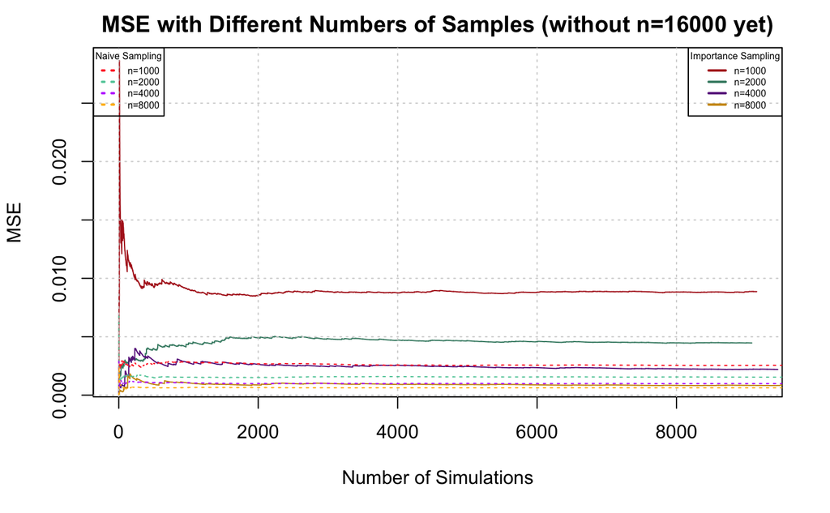

```r
legend('topleft',
       bg="transparent",
       c("n=1000", "n=2000", "n=4000", "n=8000"),
       lty = c("dotted"),
       col = c("firebrick1", "mediumaquamarine", "darkorchid1", "darkgoldenrod1"),
       bty = 'y',
       lwd = 2,
       title = "Naive Sampling",
       title.col = "black",
       cex = 0.5)
```

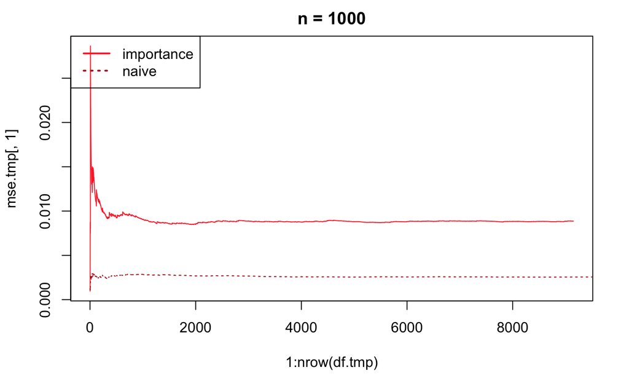

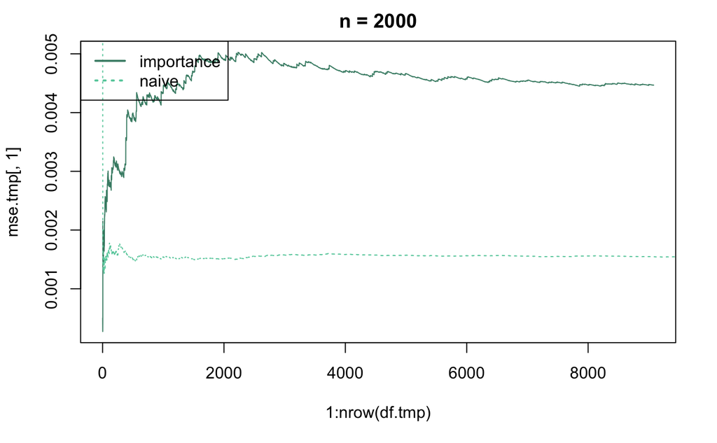

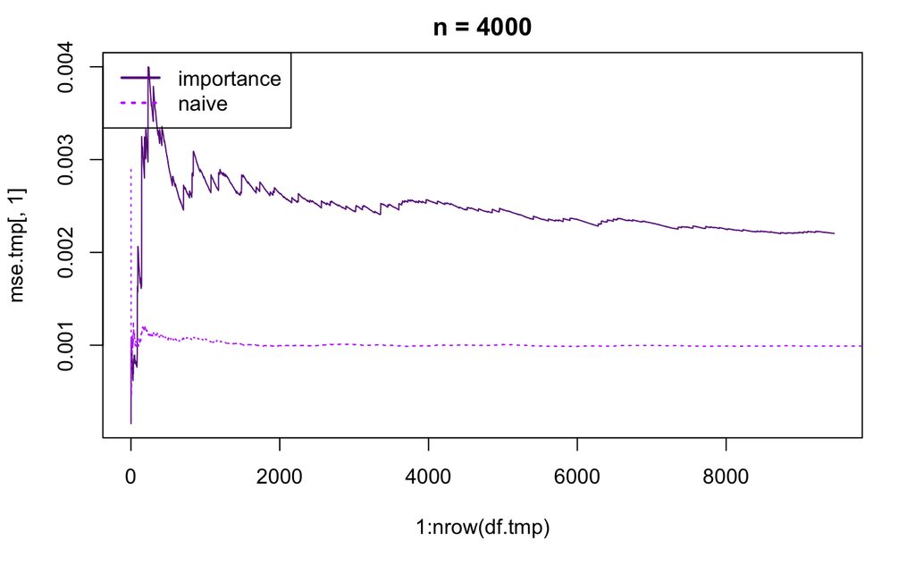

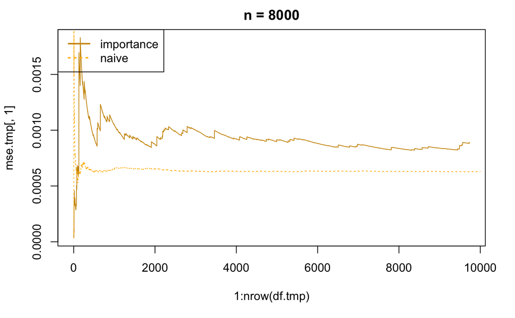

## Scale MSE by n

```r
df.tmp <- results1000
var(data.frame(df.tmp[which(df.tmp>0 & df.tmp<0.9)]))[1] # 0.006798412
```

```
[1] 0.006798412
```

```r
var(data.frame(df.tmp[which(df.tmp>0 & df.tmp<0.9)]))[1] * 1000 # 6.798412
```

```
[1] 6.798412
```

```r
df.tmp <- results2000
var(data.frame(df.tmp[which(df.tmp>0 & df.tmp<0.9)]))[1] # 0.003818471
```

```
[1] 0.003818471
```

```r
var(data.frame(df.tmp[which(df.tmp>0 & df.tmp<0.9)]))[1] * 2000 # 7.636942
```

```
[1] 7.636942
```

```r
df.tmp <- results4000
var(data.frame(df.tmp[which(df.tmp>0 & df.tmp<0.9)]))[1] # 0.001812862
```

```
[1] 0.001812862
```

```r
var(data.frame(df.tmp[which(df.tmp>0 & df.tmp<0.9)]))[1] * 4000 # 7.25145
```

```
[1] 7.25145
```

```r
df.tmp <- results8000
var(data.frame(df.tmp[which(df.tmp>0 & df.tmp<0.9)]))[1] # 0.0008297921
```

```
[1] 0.0008297921
```

```r
var(data.frame(df.tmp[which(df.tmp>0 & df.tmp<0.9)]))[1] * 8000 # 6.638337
```

```
[1] 6.638337
```

```r
df.tmp <- results16000
var(data.frame(df.tmp[which(df.tmp>0 & df.tmp<0.9)]))[1] # 0.0008297921
```

```
[1] 0.0001854293
```

```r
var(data.frame(df.tmp[which(df.tmp>0 & df.tmp<0.9)]))[1] * 16000 # 6.638337
```

```
[1] 2.966869
```